# Principal Component Analysis

In this block we:

```
* ...recap the Principal Component Analysis
* ...show one possible usage of the PCA for cluster analysis
* ...find an example when it does not work
* ...extend the PCA by using kernels
* ...turn the PCA "quantum"
```

# The Data Matrix and the Principal Component Analysis

- The Principal Component Analysis is a popular statistical technique
  - Transform a set of data X into a new orthogonal basis
  - Directions of the new basis are ordered in terms of variance contribution to the overall variance.
- We consider a $p$-dimensional vector of features observed $n$ times
- Let us denote the $n\times p$ dimensional matrix of data as $X$.

# The Data Matrix

- In general, the data matrix $X$ is rectangular
- Eigenvalues are not defined for rectangular matrices.
- Singular values:
  - The right and left singular values for a rectangular matrix $X$ are the square roots of the eigenvalues of $X^{T}X$ and $XX^{T}$.
- The corresponding eigenvectors – the right and left singular vectors, respectively.

What exactly do these matrices, $M^{T}M$ and $MM^{T}$ mean in terms of statistics?

- $x$ corresponds to observations – $p$-dimensional vector random variable
- We assume $x$ is a column vector $x\in\Re^{p\times1}$
- The samples---realisations of the random variable $x$---occur as the rows of $X$, not as columns

# PCA: The First Principal Component

- Let us introduce the Principal Components of the data.
- We focus on the calculation of the first principal component.
- We consider dataset with $p$ features.
  - We model our data as a $p$-dimensional random variable ${x}\in\Re^{p\times1}$.
- The objective of the first principal component:
  - To find a vector of weights ${w}_{(1)}\in\Re^{p\times1}$ such that the variance of the scalar random variable ${x^{T}}{w}_{(1)}$ is maximized.
  - Thus our objective is to find

$$ \max\limits _{{w}_{(1)}}\,Var[x^{T}{w}_{(1)}]\,.$$

# PCA: The First Principal Component

- We assume that we are given a data matrix with n observations, ${X}\in\Re^{n\times p}$.
- Let us consider the centred data matrix ${X}'$.
- We have already argued that the sample covariance matrix:

$${Q}=\frac{1}{n-1}\left({X}'\right)^{T}{X}'$$

is an unbiased estimator of the covariance matrix $Var[{x}]$.

- Moreover, by the properties of variances,

$$Var[x^{T}{w}_{(1)}]={w^{T}}_{(1)}Var[{x}]{w}_{(1)}={w^{T}}_{(1)}{\Sigma}{w}_{(1)}\,.$$

- In practice, however, we don't have access to ${\Sigma}$ – at best, we can get unbiased estimator ${C}$, namely the sample covariance matrix:

$${C}={Q}=\frac{1}{n-1}\left({X}'\right)^{T}{X}'\,.$$

- Thus our maximization problem becomes:

$$\max\limits _{{w}_{(1)}}\,{w^{T}}_{(1)}{C}{w}_{(1)}\,.$$

# PCA: The First Principal Component

- Let us add another requirement (another constraint): we want our weights, ${w}_{(1)}$, to be a unit vector:

$${w^{T}}_{(1)}{w}_{(1)}=1\,.$$

- Equivalently, we can add a penalty to the objective function for any deviation from zero of ${w^{T}}_{(1)}{w}_{(1)}-1$:

$$\max\limits _{{w}_{(1)}}\,{w^{T}}_{(1)}{C}{w}_{(1)}-\lambda_{(1)}({w^{T}}_{(1)}{w}_{(1)}-1)\,,$$

where the constant $\lambda_{(1)}$ is a Lagrange multiplier.

- Let us now solve this optimization problem:

$$\frac{\partial}{\partial{w}_{(1)}}\left({w^{T}}_{(1)}{C}{w}_{(1)}-\lambda_{(1)}({w^{T}}_{(1)}{w}_{(1)}-1)\right)=0\,,$$

- computing the partial derivative on the left-hand side and rearranging this equation:

$${C}{w}_{(1)}=\lambda_{(1)}{w}_{(1)}\,.$$

# PCA: The Second Principal Component

- Objective: We look for a vector of weights ${w}_{(2)}\in\Re^{p\times1}$ such ${w}_{(2)}$ is orthogonal to ${w}_{(1)}$ and the variance of the scalar random variable $x^{T}{w}_{(2)}$ is maximized.
  - We want this vector to be a unit vector, ${w^{T}}_{(2)}{w}_{(2)}=1$.
  - Since it is orthogonal to ${w}_{(1)}$, ${w^{T}}_{(1)}{w}_{(2)}=0$.
  - We can add this as a constraint to our optimization problem:

$$\max\limits _{{w}_{(2)}}\,{w^{T}}_{(2)}{C}{w}_{(2)}-\lambda_{(2)}({w^{T}}_{(2)}{w}_{(2)}-1)-\nu_{(1)}{w^{T}}_{(1)}{w}_{(2)}\,,$$

- where $\lambda_{(2)}$ is the Lagrange multiplier corresponding to the unit vector constraint and $\nu_{(1)}$ the Lagrange multiplier corresponding to the orthogonality constraint.

# PCA: The (any) Principal Component

We can generalize this process and obtain:

- The eigenvalue, $\lambda_{(1)}$, and the corresponding eigenvector ${w}_{(1)}$, of ${C}$, such that $Var[{x^{T}}{w}_{(1)}]\approx{{w^{T}}_{(1)}}{C}{w}_{(1)}=\lambda_{(1)}$;
- The eigenvalue, $\lambda_{(2)}\leq\lambda_{(1)}$, and the corresponding eigenvector ${w}_{(2)}$, of ${C}$, such that $Var[{x^{T}}{w}_{(2)}]\approx{{w^{T}}_{(2)}}{C}{w}_{(2)}=\lambda_{(2)}$;
- The eigenvalue, $\lambda_{(3)}\leq\lambda_{(2)}$, and the corresponding eigenvector ${w}_{(3)}$, of ${C}$, such that $Var[{x^{T}}{w}_{(3)}]\approx{{w^{T}}_{(3)}}{C}{w}_{(3)}=\lambda_{(3)}$;
- $\vdots$
- The eigenvalue, $\lambda_{(p)}\leq\lambda_{(p-1)}$, and the corresponding eigenvector ${w}_{(p)}$, of ${C}$, such that $Var[{x^{T}}{w}_{(p)}]\approx{{w^{T}}_{(p)}}{C}{w}_{(p)}=\lambda_{(p)} $

# PCA-based Dimensionality Reduction, Clustering and Outlier Detection

## Dimensionality Reduction

- The $p$-dimensional dataset
  - Calculate first $k$ Principal Components (first $k$ largest eigenvalues and corresponding eigenvectors)
  - Obtain first $k$ projections of the data
  - $X\to \tilde{X}$
    - This can provide improvement when $n$ is small
    - Decreasing load on the system (high-frequency systems)
    - The maximum variance (variability?) in the model preserved

## Clustering

- Data can be composed of several clusters
- PCA decomposition allows us to recognise such clusters
  - The principal components will be easy to cluster (linearly separable features)
- PCA works on data centered around zero
  - Co-centric clusters

## Outlier Detection

- Extreme version of clustering

The workflow is as follows:

- Perform dimensionality reduction of large-dimensional data set and then find outliers in the low-dimensional space
- This is a tool to decrease the dimensionality of the problem, not a methor per se
  - Turning it into a statistical method requires some further assumption (outlier = extreme values etc)
  - Example: fradulent transactions

```python
# Load data, we will use the Boston dataset

import numpy as np
import pandas as pd
from sklearn.datasets import load_boston

dataBoston = load_boston()

# We do not need target variable
df = pd.DataFrame(dataBoston.data, columns=dataBoston.feature_names)
```

[output not shown]

```python
# Estimate the PCA, only the first component is needed

# Load PCA
from sklearn.decomposition import PCA

# Data
X = df.values

# PCA with one component
pca = PCA(n_components=1)

# Fit PCA
pca.fit(X)

# PCA component -- first eigenvector * data
pcaX = np.matmul(X,pca.components_[0])
```

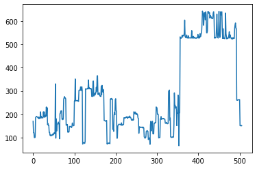

```python
# Visualise the outcome
import matplotlib.pyplot as plt
plt.plot(pcaX);
```

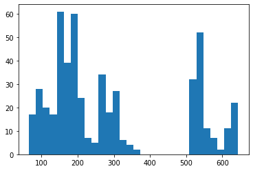

```python
# Histogram is more suitable
plt.hist(pcaX, bins=30);
```

```python
Xcluster1=X[pcaX>450]
Xcluster2=X[pcaX<=450]
```

# Kernel PCA

- Let us apply the PCA on the following dataset.

```python
from sklearn.datasets import make_circles
from sklearn.model_selection import train_test_split

X, y = make_circles(n_samples=1_000, factor=0.3, noise=0.05, random_state=0)
```

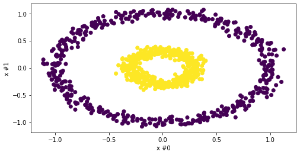

```python
fig, ax = plt.subplots(figsize=(8, 4))

ax.scatter(X[:, 0], X[:, 1], c=y)
ax.set_ylabel("x #1")
ax.set_xlabel("x #0")
```

- Data are centered around the origin
- Apply PCA

```python
from sklearn.decomposition import PCA

pca = PCA(n_components=2)

# fit and project at the same time
X_pca = pca.fit(X).transform(X)
```

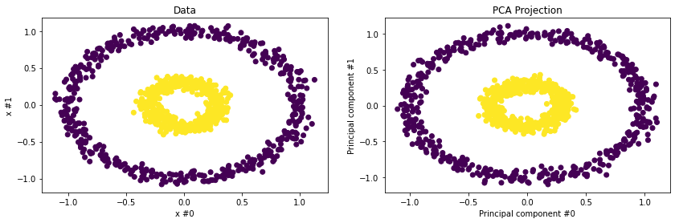

```python
fig, (ax1,ax2) = plt.subplots(
    ncols=2, figsize=(14, 4)
)

ax1.scatter(X[:, 0], X[:, 1], c=y)
ax1.set_ylabel("x #1")
ax1.set_xlabel("x #0")
ax1.set_title("Data")

ax2.scatter(X_pca[:, 0], X_pca[:, 1], c=y)
ax2.set_ylabel("Principal component #1")
ax2.set_xlabel("Principal component #0")
ax2.set_title("PCA Projection")
```

- Projection leaves data nearly identical
- In the case of the Boston data, we have been able to identify clusters of data based on the first principal component.
  - In this case, we see two clusters, but we are not able to recongise them
  - PCA works with data centered around zero
- Let us use rbf kernel (and then say what we actually did)

```python
from sklearn.decomposition import KernelPCA

kernel_pca = KernelPCA(n_components=None, kernel="rbf", gamma=10, alpha=0.1)
```

```python
X_pcaKernel = kernel_pca.fit(X).transform(X)
```

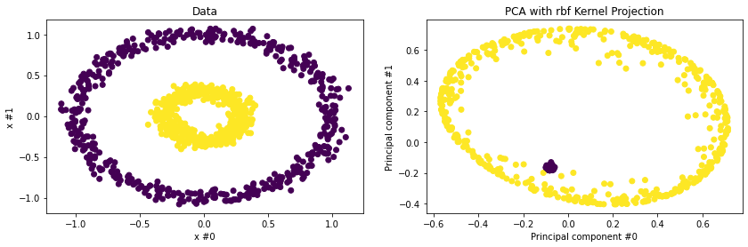

```python
fig, (ax1,ax2) = plt.subplots(
    ncols=2, figsize=(14, 4)
)

ax1.scatter(X[:, 0], X[:, 1], c=y)
ax1.set_ylabel("x #1")
ax1.set_xlabel("x #0")
ax1.set_title("Data")

ax2.scatter(X_pcaKernel[:, 0], X_pcaKernel[:, 1], c=y)
ax2.set_ylabel("Principal component #1")
ax2.set_xlabel("Principal component #0")
ax2.set_title("PCA with rbf Kernel Projection")
```

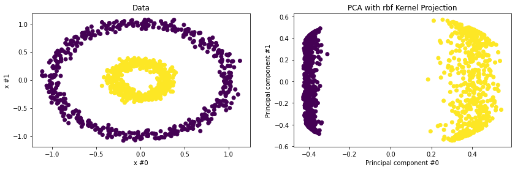

```python
# Fine tune parameters
kernel_pca = KernelPCA(n_components=None, kernel="rbf", gamma=3, alpha=0.1)

X_pcaKernel = kernel_pca.fit(X).transform(X)

fig, (ax1,ax2) = plt.subplots(
    ncols=2, figsize=(14, 4)
)

ax1.scatter(X[:, 0], X[:, 1], c=y)
ax1.set_ylabel("x #1")
ax1.set_xlabel("x #0")
ax1.set_title("Data")

ax2.scatter(X_pcaKernel[:, 0], X_pcaKernel[:, 1], c=y)
ax2.set_ylabel("Principal component #1")
ax2.set_xlabel("Principal component #0")
ax2.set_title("PCA with rbf Kernel Projection")
```

- We have been able to separate two clusters!
- For completeness, let us consider linearly separable blobs.

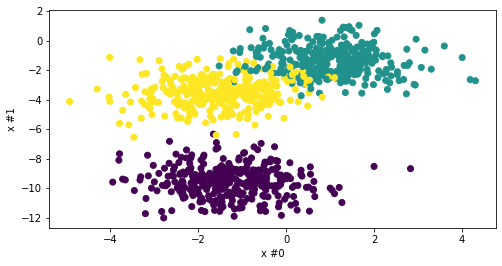

```python
from sklearn.datasets import make_blobs
from sklearn.model_selection import train_test_split

X, y = make_blobs(n_samples=1_000, random_state=2)

fig, ax = plt.subplots(figsize=(8, 4))

ax.scatter(X[:, 0], X[:, 1], c=y)
ax.set_ylabel("x #1")
ax.set_xlabel("x #0")
```

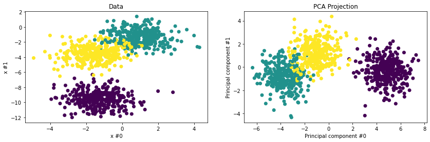

```python
from sklearn.decomposition import PCA

pca = PCA(n_components=2)

# fit and project at the same time
X_pca = pca.fit(X).transform(X)

fig, (ax1,ax2) = plt.subplots(
    ncols=2, figsize=(14, 4)
)

ax1.scatter(X[:, 0], X[:, 1], c=y)
ax1.set_ylabel("x #1")
ax1.set_xlabel("x #0")
ax1.set_title("Data")

ax2.scatter(X_pca[:, 0], X_pca[:, 1], c=y)
ax2.set_ylabel("Principal component #1")
ax2.set_xlabel("Principal component #0")
ax2.set_title("PCA Projection")
```

# Kernel PCA and its Quantum Counterpart

We are ready to introduce the kernel PCA:

- We have used the sample covariance matrix:

$${Q}=\frac{1}{n-1}\left({X}'\right)^{T}{X}'$$

which stands for:

$${Q}=\frac{1}{n-1}\sum_{i=1}^{n}\left({x_i}\right){x_i}^{T}\,.$$

- We assume $x_i$ is a column of length $p$, the product is not a dot product.

We can perform a kernel trick and project every observation $x$ from the $p$-dimensional feature space into $\tilde{p}$-dimensional space using a transform $f$.

$$\tilde{x} = f(x)\,.$$

# Kernel PCA and its Quantum Counterpart

We can calculate:

$$\tilde{Q}=\frac{1}{n-1}\sum_{i=1}^{n}\left({\tilde{x}_i}\right){\tilde{x}_i}^{T}\,.$$

The sample covariance matrix is a $\tilde{p}\times\tilde{p}$ matrix.

- This will result in the components in the $\tilde{p}$-dimensional space.
- We are interested in the original feature space
- Formulation above does not involve kernels

Let us calculate the PCA in the $\tilde{p}$-dimensional space nevertheless.

Objective:

- all egienvalues $\lambda\geq0$
- corresponding egenvectors $V$

such that

$$\lambda V = \tilde{Q} V\,.$$

Given that $V$ lies in the span of $\tilde{x}_1,\dots,\tilde{x}_n$, we can write the problem:

$$\lambda \tilde{x}_k \cdot V = \tilde{x}_k \cdot\tilde{Q} V\,.$$

for every $k=1,\dots,n$, with decomposition:

$$V = \sum_{i=1}^{n} \alpha_i \tilde{x}_i\,. $$

Now, we can introduce kernel $K$:

$$K(x_i,x_j) = K_{i,j} = \tilde{x}_i \cdot \tilde{x}_i\,,$$

and thus

$$n \lambda K = K^2 \vec{\alpha}\,,$$

with $\vec{\alpha}$ being a column vector of individual $\alpha$'s.

- The calculation further requires normalisation and some other numerical oprations. However, we do not need the explicit form of $f$, we may work with kernel only.
- Further, we may use $\tilde{p}=p$, the kernel just warps the space.

# Quantum Kernel

- Introducing quantum kernel is now straightforward -- we use kernel based on quantum computing
- Objective:
  - Implemenet it with Qiskit
  - Find problems, where the quantum kernel shows dominance (open problem for us)

```python
# Usual Import

# Import basic object from the Qiskit
from qiskit import QuantumCircuit
from qiskit import Aer,BasicAer
from qiskit import execute

# We will need these two
from qiskit.utils import QuantumInstance
from qiskit_machine_learning.kernels import QuantumKernel

# Load account from the disk
from qiskit import IBMQ
IBMQ.load_account()
```

```
<AccountProvider for IBMQ(hub='ibm-q', group='open', project='main')>
```

```python
# Check the version of the qiskit you use

# Compared to previous class, I have installed the up-to-date version
import qiskit.tools.jupyter
%qiskit_version_table
%qiskit_copyright
```

Version Information

| Qiskit Software | Version |
| --- | --- |
| `qiskit-terra` | 0.19.2 |
| `qiskit-aer` | 0.10.3 |
| `qiskit-ignis` | 0.7.0 |
| `qiskit-ibmq-provider` | 0.18.3 |
| `qiskit` | 0.34.2 |
| `qiskit-machine-learning` | 0.3.1 |
| System information |  |
| Python version | 3.8.12 |
| Python compiler | Clang 10.0.0 |
| Python build | default, Oct 12 2021 06:23:56 |
| OS | Darwin |
| CPUs | 4 |
| Memory (Gb) | 8.0 |
| Sat Mar 12 19:01:40 2022 GMT |  |

This code is a part of Qiskit

© Copyright IBM 2017, 2022.

```python
# Ideal simulator
simulator = Aer.get_backend('qasm_simulator')
```

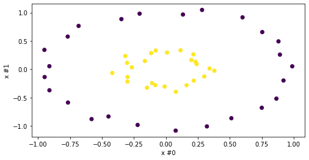

```python
from sklearn.datasets import make_circles
# We split the data into testing and training parts
from sklearn.model_selection import train_test_split

X, y = make_circles(n_samples=50, factor=0.3, noise=0.05, random_state=0)
X_train, X_test, y_train, y_test = train_test_split(X, y, stratify=y, random_state=0)



fig, ax = plt.subplots(figsize=(8, 4))

ax.scatter(X[:, 0], X[:, 1], c=y)
ax.set_ylabel("x #1")
ax.set_xlabel("x #0")
```

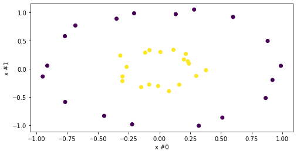

```python
fig, ax = plt.subplots(figsize=(8, 4))

ax.scatter(X_train[:, 0], X_train[:, 1], c=y_train)
ax.set_ylabel("x #1")
ax.set_xlabel("x #0")
```

```python
# dimension of problem (number of qubits)
nQubits = X_train.shape[1]
# number of repetitions
nReps = 1

# Define Feature map, Pauli-Z evolution circuit
from qiskit.circuit.library import ZZFeatureMap

featureMap = ZZFeatureMap(feature_dimension=nQubits, reps=nReps, entanglement="linear")
```

```python
from qiskit.utils import QuantumInstance

backendSim = QuantumInstance(
    BasicAer.get_backend("qasm_simulator"), shots=1024
)
```

```python
# define Quantum kernel using the above feature map
kernelQuantum = QuantumKernel(feature_map=featureMap, quantum_instance=backendSim)
```

## Kernel is not callable

- We will not use callable kernel as we did in QSVM, we will perform kernel transform explicitly.
- This makes notation few more lines longer -- in case of repeated use of this, we can wrap it into a simple function (or even create class) which will perform those steps under the hood

```python
# We define
K = kernelQuantum.evaluate(X_train,X_train)
```

```python
# We call this kernel quantum, but there is nothing quantum inside
# The quantum part will come below, when we use as input the kernel instead of individual observation
kernelPCAquantum = KernelPCA(n_components=None, kernel="precomputed")
```

```python
# Fit (=find eigensystem) and then transform the data using PCA with precalculated kernel

transformed_x = kernelPCAquantum.fit_transform(K)
```

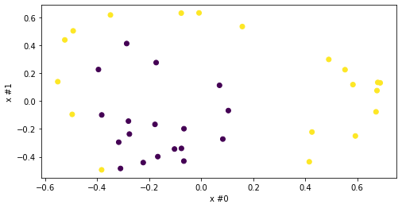

```python
fig, ax = plt.subplots(figsize=(8, 4))

ax.scatter(transformed_x[:, 0], transformed_x[:, 1], c=y_train)
ax.set_ylabel("x #1")
ax.set_xlabel("x #0")
ax2.set_title("PCA Projection with Quantum Kernel, in-sample")
```

- We have achieved some improvement in terms of separability of clusters!

```python
# Out of sample calculation
Ktest = kernelQuantum.evaluate(X_test,X_train)
```

```python
# Projection
transformed_xTest = kernelPCAquantum.transform(Ktest)
```

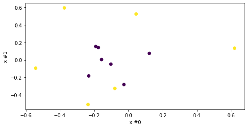

```python
fig, ax = plt.subplots(figsize=(8, 4))

ax.scatter(transformed_xTest[:, 0], transformed_xTest[:, 1], c=y_test)
ax.set_ylabel("x #1")
ax.set_xlabel("x #0")
ax2.set_title("PCA Projection with Quantum Kernel, out-of-sample")
```

- Out of sample performance is not as convincing as in-sample

### Further Tasks

- Try to find the best kernel
- Analyse how the problem scales with sample size
- How is the problem affected by the real quantum computer (aka simulation with noise)